# van Kessel Nitrospira 1 Comammox

Mads Albertsen

November 24, 2015

## Introduction

This report documents the binning of a Nitrospira Comammox genome from an enrichment reactor. See [vanKessel et al., 2015: Complete nitrification by a single microorganism](http://dx.doi.org/10.1038/nature16459) for further details.

## Load the mmgenome package

In case you haven’t installed the [mmgenome package](http://madsalbertsen.github.io/mmgenome/), see the [Load data example](http://madsalbertsen.github.io/mmgenome/Load_data.html).

```r
library("mmgenome")
```

## Import data

The Rmarkdown file [Load_data.Rmd](http://madsalbertsen.github.io/mmgenome/vanKessel_Load_data.html) describes the data that is to be loaded. The data is then loaded using the `mmimport` function. The data loading and genome extraction is split to enable cleaner workflows. I.e. you load data once, but extract multiple genomes in their separate Rmarkdown file.

```r
load("vanKessel.RData")
```

## Data overview

The object `d` contains information on scaffolds and essential genes within the scaffolds. For each scaffold the dataset contains the following information: The columns `CTAB`, `KITpe`, `KITmp` and `KIT` contain the coverage information from 4 different samples; `PC1`, `PC2` and `PC3` contain coordinates of the three first principal components from a PCA analysis on tetranucleotide frequencies; `essential` contain information taxonomic information for each scaffold based on classification on essential genes; `rRNA16S` contain taxonomic information on scaffolds that have an associated 16S rRNA gene.

```r
colnames(d$scaffolds)
```

```
##  [1] "scaffold"  "length"    "gc"        "CTAB"      "KITpe"
##  [6] "KITmp"     "KIT"       "PC1"       "PC2"       "PC3"
## [11] "essential" "rRNA16S"
```

The basic statistics of the full dataset can be summarised using the `mmstats` function.

```r
mmstats(d, ncov = 4)
```

```
##                General Stats
## n.scaffolds         47584.00
## GC.mean                53.90
## N50                  6256.00
## Length.total    178755569.00
## Length.max        1528908.00
## Length.mean          3756.60
## Coverage.CTAB           5.81
## Coverage.KITpe          4.55
## Coverage.KITmp          6.76
## Coverage.KIT           11.31
## Ess.total            3158.00
## Ess.unique            109.00
```

## Nitrospira 1

### Initial subspace extraction (Figure ED2a)

In general, the metagenome assembly is very nice and the two Nitrospira genomes can easily be identified. The first Nitrospira genome is located in the same coverage space as a genome from the Phylum Planctomycetes. However, that is removed in the subsequent steps.

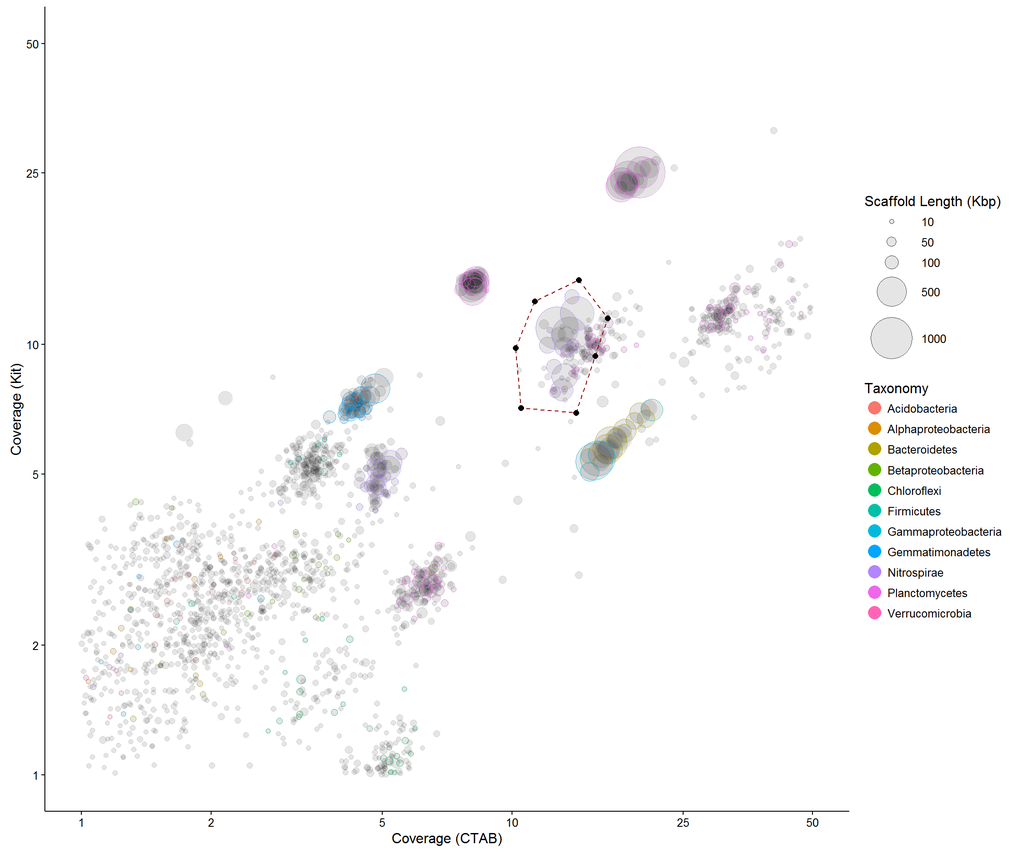

```r
p <- mmplot(data = d,
            x = "CTAB",
            y = "KITpe",
            color = "essential",
            minlength = 10000)

#p
#sel <- mmplot_locator(p)

sel <- data.frame(CTAB  =  c(10.2, 11.3, 14.3, 16.7, 15.6, 14.1, 10.5),
                  KITpe  =  c(9.82, 12.6, 14.1, 11.5, 9.39, 6.93, 7.12))

mmplot_selection(p, sel)  +
  scale_x_log10(limits = c(1,50), breaks = c(1, 2, 5, 10, 25, 50)) +
  scale_y_log10(limits = c(1,50), breaks = c(1, 2, 5, 10, 25, 50)) +
  scale_size_area(breaks = c(10000, 50000,  100000, 500000, 1000000),
                  max_size = 20, labels = c(10, 50, 100, 500, 1000),
                  name = "Scaffold Length (Kbp)") +
  scale_color_discrete(name = "Taxonomy") +
  xlab("Coverage (CTAB)") +
  ylab("Coverage (Kit)") +
  theme_classic()
```

The scaffolds included in the defined subspace are extracted using the `mmextract` function. Note that all scaffolds in the defined subspace is extracted and not just the scaffolds over 10 kbp that was plotted.

```r
dA <- mmextract(d, sel)
```

The `mmstats` function applies to any extracted object. Hence, it can be used directly on the subset.

```r
mmstats(dA)
```

```
##                General Stats
## n.scaffolds           311.00
## GC.mean                50.70
## N50                152547.00
## Length.total      6975425.00
## Length.max        1073143.00
## Length.mean         22429.00
## Coverage.CTAB          13.69
## Coverage.KITpe         10.07
## Ess.total             152.00
## Ess.unique            106.00
```

## Identify the next relevant variables for subsetting

The function `mmplot_pairs` can visualize a number of different variables at the same time. In this case `PC2` and `PC3` seem like a good choice.

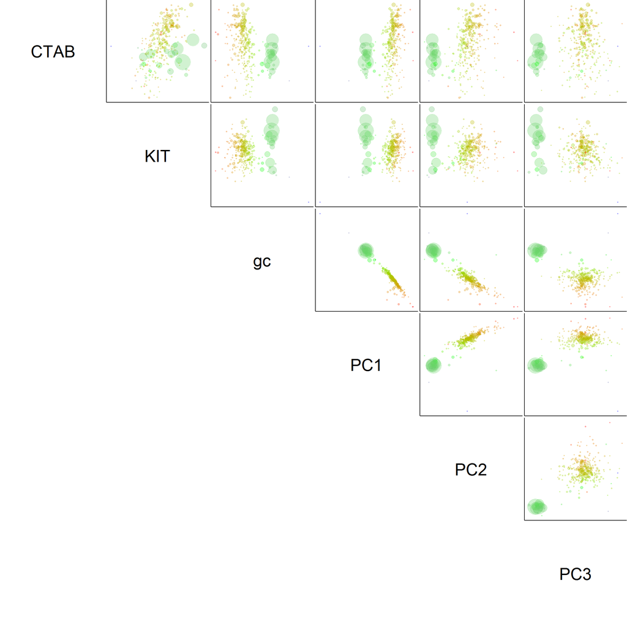

```r
mmplot_pairs(data = dA, variables = c("CTAB", "KIT", "gc", "PC1", "PC2", "PC3"))
```

## Subspace extraction 2 (Figure ED2a-insert)

We use the same procedure as with the initial subset. However, now the `dA` subset is used as input data.

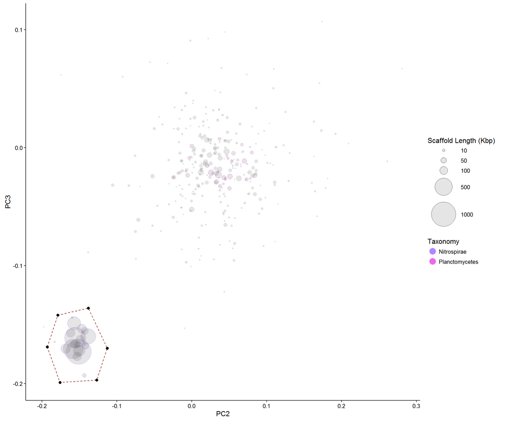

```r
p <- mmplot(data = dA,
            x = "PC2",
            y = "PC3",
            color = "essential")

#p
#sel <- mmplot_locator(p)

sel <- data.frame(PC2  =  c(-0.193, -0.179, -0.138, -0.113, -0.127, -0.176),
                  PC3  =  c(-0.169, -0.142, -0.136, -0.17, -0.197, -0.199))

mmplot_selection(p, sel)  +
  scale_size_area(breaks = c(10000, 50000,  100000, 500000, 1000000),
                  max_size = 20, labels = c(10, 50, 100, 500, 1000),
                  name = "Scaffold Length (Kbp)") +
  scale_color_manual(name = "Taxonomy", values = cols[c(9,10)]) +
  theme_classic()
```

```r
dB <- mmextract(dA, sel)
```

```r
mmstats(dB)
```

```
##                General Stats
## n.scaffolds               19
## GC.mean                   55
## N50                   659693
## Length.total         4400979
## Length.max           1073143
## Length.mean           231631
## Coverage.CTAB             13
## Coverage.KITpe            10
## Ess.total                104
## Ess.unique               103
```

## Using paried-end connections

Until now we have just used coverage profiles to extract scaffolds related to our genome of interest. However, some scaffolds might be present in many copies (repeats) and hence have a much higher coverage than the rest of the genome. In addition, some scaffolds will by chance have a slightly different coverage profile than the rest of the genome and thereby also be missed.

The function `mmplot_network` can be used to generate a network plot of scaffolds connected by paired-end reads. We start by plotting the scaffolds we have in our current subset.

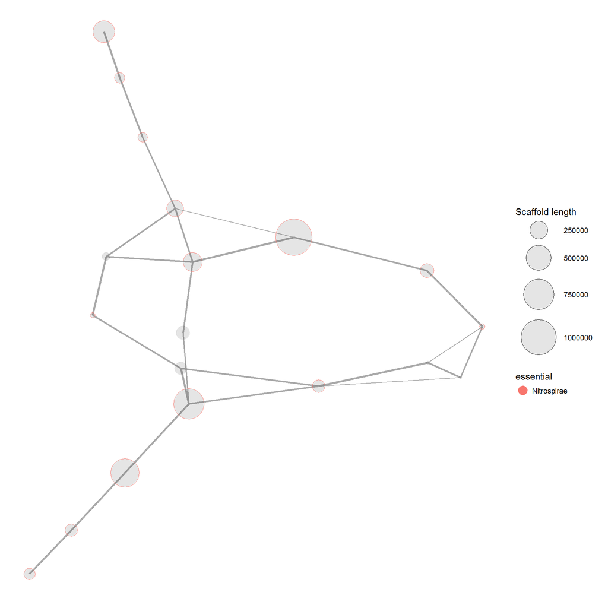

```r
mmplot_network(data = dB, network = mp, nconnections = 5, color = "essential", scale.links = 0.5)
```

To include repeats and other missed scaffolds we simply extract all scaffolds that are directly connected by mate-pair reads to our current subset `dB` using `mmextract_network`. Only scaffolds directly connected to the subset is extracted.

```r
dC <- mmextract_network(subset = dB, original = d, network = mp, nconnections = 5, type = "direct")
```

… and then plot the new subset.

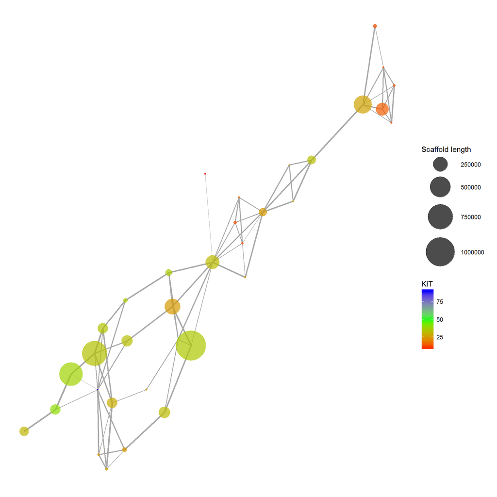

```r
mmplot_network(data = dC, network = mp, nconnections = 5, color = "KIT", scale.links = 0.5)
```

## Subspace extraction 3

We finally remove the low abundant Nitrospira scaffolds that were included using the mate-pair data.

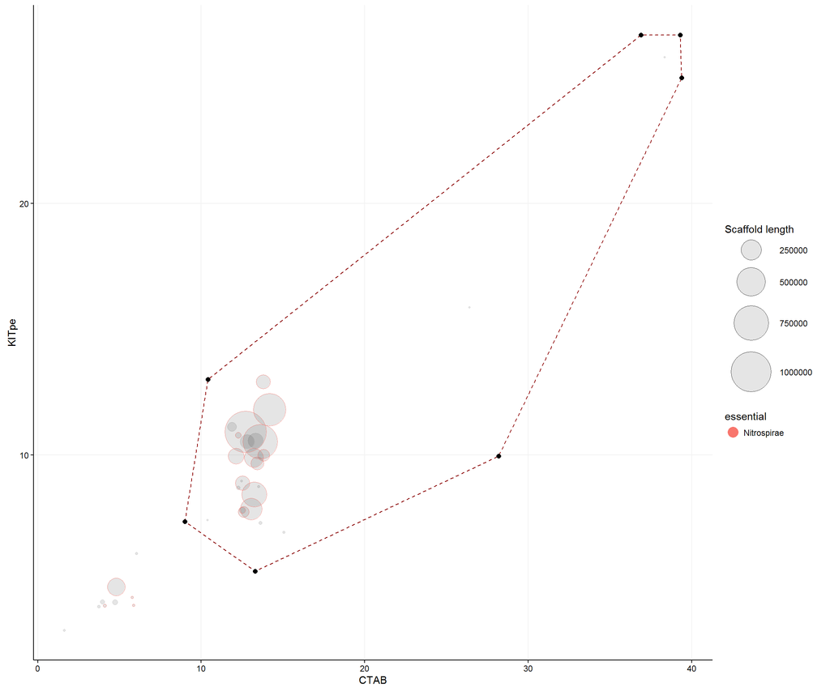

```r
p <- mmplot(data = dC,
            x = "CTAB",
            y = "KITpe")

#p
#sel <- mmplot_locator(p)

sel <- data.frame(CTAB  =  c(8.99, 10.4, 36.9, 39.3, 39.4, 28.2, 13.3),
                  KITpe =  c(7.35, 13, 26.7, 26.7, 25, 9.95, 5.37))

mmplot_selection(p, sel)
```

```r
dD <- mmextract(dC, sel)
```

```r
mmstats(dD)
```

```
##                General Stats
## n.scaffolds               25
## GC.mean                   55
## N50                   659693
## Length.total         4413075
## Length.max           1073143
## Length.mean           176523
## Coverage.CTAB             13
## Coverage.KITpe            10
## Ess.total                104
## Ess.unique               103
```

## Export the scaffolds

Now that we are happy with the genome bin, the scaffolds can be exported to a separate fasta file using `mmexport`.

```r
mmexport(data=dD, assembly=assembly, file = "Nitrospira1.fa")
```

## Final network plot (Figure ED2c)

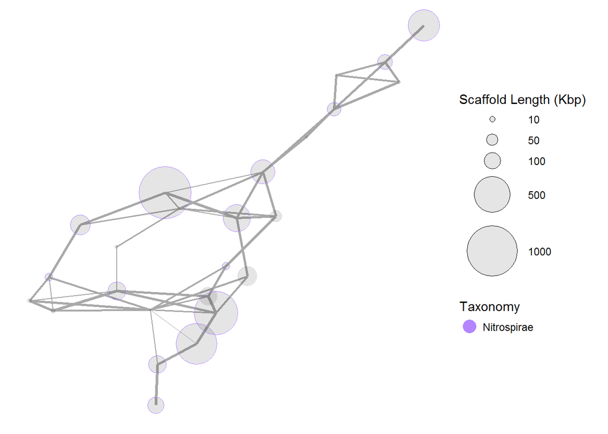

```r
mmplot_network(data = dD,
               network = mp,
               nconnections = 5,
               color = "essential",
               scale.links = 0.5) +
  scale_size_area(breaks = c(10000, 50000,  100000, 500000, 1000000),
                  max_size = 20, labels = c(10, 50, 100, 500, 1000),
                  name = "Scaffold Length (Kbp)") +
  scale_color_manual(name = "Taxonomy", values = cols[c(9)])
```